# Machine Learning - Data Preparation & Feature Selection (Lasso)

## Set Up

```r
 #install.packages("glmnet")
# install.packages("ggplot2")
 #install.packages("naniar")
 #install.packages("OneR")
 #install.packages("mice")
library(glmnet) # Load glmnet for lasso
library(ggplot2) # Load ggplot2 for visualizations
library(naniar) # Load nanair for missing data visualization
library(OneR) # Load OneR for binning function
library(mice) # Load mice for missing data inputation
library(plotmo) # for plot_glmnet for lasso visualization
```

For this analysis we wish to determine which factors play a role in determining the life expectancy in different countries. For this we have gathered data from different countries, the life expectancy in the country for that year and some public health variables.

```r
load("life_expectancy.rda")
```

## Data Preparation

First lets work through some data preparation. As a first step we can view the dataset:

```r
head(life)
```

```
##       Country Year     Status Life.expectancy Adult.Mortality infant.deaths
## 1 Afghanistan 2015 Developing            65.0             263            62
## 2 Afghanistan 2014 Developing            59.9             271            64
## 3 Afghanistan 2013 Developing            59.9             268            66
## 4 Afghanistan 2012 Developing            59.5             272            69
## 5 Afghanistan 2011 Developing            59.2             275            71
## 6 Afghanistan 2010 Developing            58.8             279            74
##   Alcohol percentage.expenditure Hepatitis.B Measles  BMI under.five.deaths
## 1    0.01              71.279624          65    1154 19.1                83
## 2    0.01              73.523582          62     492 18.6                86
## 3    0.01              73.219243          64     430 18.1                89
## 4    0.01              78.184215          67    2787 17.6                93
## 5    0.01               7.097109          68    3013 17.2                97
## 6    0.01              79.679367          66    1989 16.7               102
##   Polio Total.expenditure Diphtheria HIV.AIDS       GDP Population
```

[output cut: 20 more lines]

```r
tail(life)
```

```
##       Country Year     Status Life.expectancy Adult.Mortality infant.deaths
## 2933 Zimbabwe 2005 Developing            44.6             717            28
## 2934 Zimbabwe 2004 Developing            44.3             723            27
## 2935 Zimbabwe 2003 Developing            44.5             715            26
## 2936 Zimbabwe 2002 Developing            44.8              73            25
## 2937 Zimbabwe 2001 Developing            45.3             686            25
## 2938 Zimbabwe 2000 Developing            46.0             665            24
##      Alcohol percentage.expenditure Hepatitis.B Measles  BMI under.five.deaths
## 2933    4.14               8.717409          65     420 27.5                43
## 2934    4.36               0.000000          68      31 27.1                42
## 2935    4.06               0.000000           7     998 26.7                41
## 2936    4.43               0.000000          73     304 26.3                40
## 2937    1.72               0.000000          76     529 25.9                39
## 2938    1.68               0.000000          79    1483 25.5                39
##      Polio Total.expenditure Diphtheria HIV.AIDS       GDP Population
```

[output cut: 20 more lines]

```r
dim(life)
```

```
## [1] 2938   22
```

We have 2938 samples in the data and 22 variables. The variables are:

- `Country` - The country the sample is for
- `Year` - The year the sample is for
- `Status` - Developed or Developing status
- `Life.expectancy` - Life Expectancy in age
- `Adult.Mortality` - Adult Mortality Rates of both sexes (probability of dying between 15 and 60 years per 1000 population)
- `infant.deaths` - Number of Infant Deaths per 1000 population
- `Alcohol` - Alcohol, recorded per capita (15+) consumption (in litres of pure alcohol)
- `percentage.expenditure` - Expenditure on health as a percentage of Gross Domestic Product per capita(%)
- `Hepatitus.B` - Hepatitis B (HepB) immunization coverage among 1-year-olds (%)
- `Measles` - Number of reported cases per 1000 population
- `BMI` - Average Body Mass Index of entire population
- `under.five.deaths` - Number of under-five deaths per 1000 population
- `Polio` - Polio (Pol3) immunization coverage among 1-year-olds (%)
- `Total.expenditure` - General government expenditure on health as a percentage of total government expenditure (%)
- `Diphtheria` - Diphtheria tetanus toxoid and pertussis (DTP3) immunization coverage among 1-year-olds (%)
- `HIV.AIDS` - Deaths per 1 000 live births HIV/AIDS (0-4 years)
- `GDP` - Gross Domestic Product per capita (in USD)
- `Population` - Population of the country
- `thinness..1.19.years` - Prevalence of thinness among children and adolescents for Age 10 to 19 (%)
- `thinness.5.9.years` - Prevalence of thinness among children for Age 5 to 9(%)
- `Income.composition.of.resources` - Human Development Index in terms of income composition of resources (index ranging from 0 to 1)
- `Schooling` - Number of years of Schooling(years)

#### Samples/Instances

For this dataset our samples will be each `Country` and `Year` combination.

```r
nrow(unique(life[, c("Country", "Year")])) # Check number of unique samples
```

```
## [1] 2938
```

Here the number of unique samples is 2,938, the same as the number of rows in our dataset so we do not have any duplicates present.

#### Response Variable

Our response variable for this analysis will be `Life.expectancy`. Lets generate a summary of our response variable.

```r
summary(life$Life.expectancy)
```

```
##    Min. 1st Qu.  Median    Mean 3rd Qu.    Max.    NA's
##   36.30   63.10   72.10   69.22   75.70   89.00      10
```

This is a continuous variable so this is a regression problem. For our response variable we have 10 missing values, imputing a response variable is not great practice so we will drop those rows:

```r
life <- life[!is.na(life$Life.expectancy),] # Drop rows which have missing values for life expectancy
```

We can see we have a minimum value of 36.30, a mean value of 69.22, a median value of 72.10 and a max value of 89.00. A median value that is higher than the mean may mean that we have some outliers on the low side of the distribution and vice-versa. Lets look at the distribution using a density plot, `geom_density`.

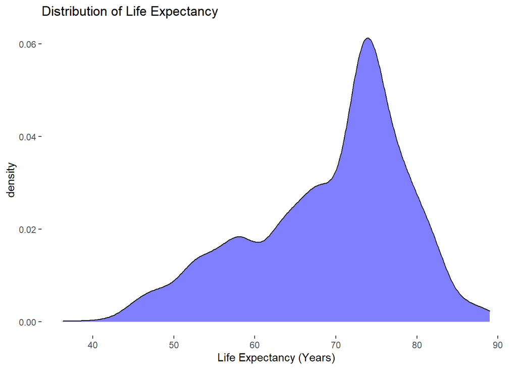

```r
g_1 <- ggplot(life, aes(x = Life.expectancy)) +
  geom_density(fill = "blue", alpha = 0.5) +
   theme_set(theme_bw(base_size = 22) ) +
  theme(panel.grid.major = element_blank(), # Remove grid
        panel.grid.minor = element_blank(), # Remove grid
        panel.border = element_blank(), # Remove grid
        panel.background = element_blank()) + # Remove grid
  labs(x = "Life Expectancy (Years)", title = "Distribution of Life Expectancy")
g_1
```

As we can see from the plot most of the samples in our database have a life expectancy of approximately 71-74 years. There are some countries with very low life expectancy of 36-40, but the distribution is not massively skewed so we should be okay to use the untransformed variable as our response.

The resolution of our dataset is on a yearly basis, an example of a lower resolution would be to use the average values for a decade while an example of a higher resolution would be to use monthly values.

#### Features

The features we will use for this analysis are:

- `Adult.Mortality`
- `infant.deaths`
- `Alcohol`
- `percentage.expenditure`
- `Hepatitus.B`
- `Measles`
- `BMI`
- `under.five.deaths`
- `Polio`
- `Total.expenditure`
- `Diphtheria`
- `HIV.AIDS`
- `GDP`
- `Population`
- `thinness..1.19.years`
- `thinness.5.9.years`
- `Income.composition.of.resources`
- `Schooling`

We can generate summary statistics for our features using the `summary()` command:

```r
# Extract feature variables
feat_vars <- names(life)[5:22]
# Summarise feature variables
summary(life[,feat_vars])
```

```
##  Adult.Mortality infant.deaths        Alcohol       percentage.expenditure
##  Min.   :  1.0   Min.   :   0.00   Min.   : 0.010   Min.   :    0.000
##  1st Qu.: 74.0   1st Qu.:   0.00   1st Qu.: 0.905   1st Qu.:    4.854
##  Median :144.0   Median :   3.00   Median : 3.770   Median :   65.611
##  Mean   :164.8   Mean   :  30.41   Mean   : 4.615   Mean   :  740.321
##  3rd Qu.:228.0   3rd Qu.:  22.00   3rd Qu.: 7.715   3rd Qu.:  442.614
##  Max.   :723.0   Max.   :1800.00   Max.   :17.870   Max.   :19479.912
##                                    NA's   :193
##   Hepatitis.B       Measles              BMI        under.five.deaths
##  Min.   : 1.00   Min.   :     0.0   Min.   : 1.00   Min.   :   0.00
##  1st Qu.:77.00   1st Qu.:     0.0   1st Qu.:19.30   1st Qu.:   0.00
##  Median :92.00   Median :    17.0   Median :43.35   Median :   4.00
##  Mean   :80.96   Mean   :  2427.9   Mean   :38.24   Mean   :  42.18
##  3rd Qu.:97.00   3rd Qu.:   362.2   3rd Qu.:56.10   3rd Qu.:  28.00
##  Max.   :99.00   Max.   :212183.0   Max.   :77.60   Max.   :2500.00
##  NA's   :553                        NA's   :32
##      Polio       Total.expenditure   Diphtheria       HIV.AIDS
##  Min.   : 3.00   Min.   : 0.37     Min.   : 2.00   Min.   : 0.100
##  1st Qu.:78.00   1st Qu.: 4.26     1st Qu.:78.00   1st Qu.: 0.100
##  Median :93.00   Median : 5.75     Median :93.00   Median : 0.100
##  Mean   :82.55   Mean   : 5.93     Mean   :82.32   Mean   : 1.748
##  3rd Qu.:97.00   3rd Qu.: 7.49     3rd Qu.:97.00   3rd Qu.: 0.800
##  Max.   :99.00   Max.   :17.60     Max.   :99.00   Max.   :50.600
##  NA's   :19      NA's   :226       NA's   :19
##       GDP              Population        thinness..1.19.years
##  Min.   :     1.68   Min.   :3.400e+01   Min.   : 0.100
##  1st Qu.:   463.85   1st Qu.:1.967e+05   1st Qu.: 1.600
##  Median :  1764.97   Median :1.392e+06   Median : 3.300
##  Mean   :  7494.21   Mean   :1.276e+07   Mean   : 4.851
##  3rd Qu.:  5932.90   3rd Qu.:7.427e+06   3rd Qu.: 7.200
##  Max.   :119172.74   Max.   :1.294e+09   Max.   :27.700
##  NA's   :443         NA's   :644         NA's   :32
##  thinness.5.9.years Income.composition.of.resources   Schooling
##  Min.   : 0.100     Min.   :0.0000                  Min.   : 0.0
##  1st Qu.: 1.575     1st Qu.:0.4930                  1st Qu.:10.1
##  Median : 3.400     Median :0.6770                  Median :12.3
##  Mean   : 4.881     Mean   :0.6274                  Mean   :12.0
##  3rd Qu.: 7.200     3rd Qu.:0.7792                  3rd Qu.:14.3
##  Max.   :28.600     Max.   :0.9480                  Max.   :20.7
##  NA's   :32         NA's   :160                     NA's   :160
```

From our summary we can see that all of our explanatory variables for this analysis are continuous features. We will not use the `Status`status of a country as an explanatory variable as it is not a particular feature we are interested in however if we view a summary of that variable we can see that it is a discrete/categorical feature:

```r
# Summarise developing/not developed status
summary(as.factor(life$Status))
```

```
##  Developed Developing
##        512       2416
```

### Missing Data Imputation

From our summary statistics we can note that there are several missing values for our dataset. To visualizse these we can use the `vis_miss()` command from the `nanair` package.

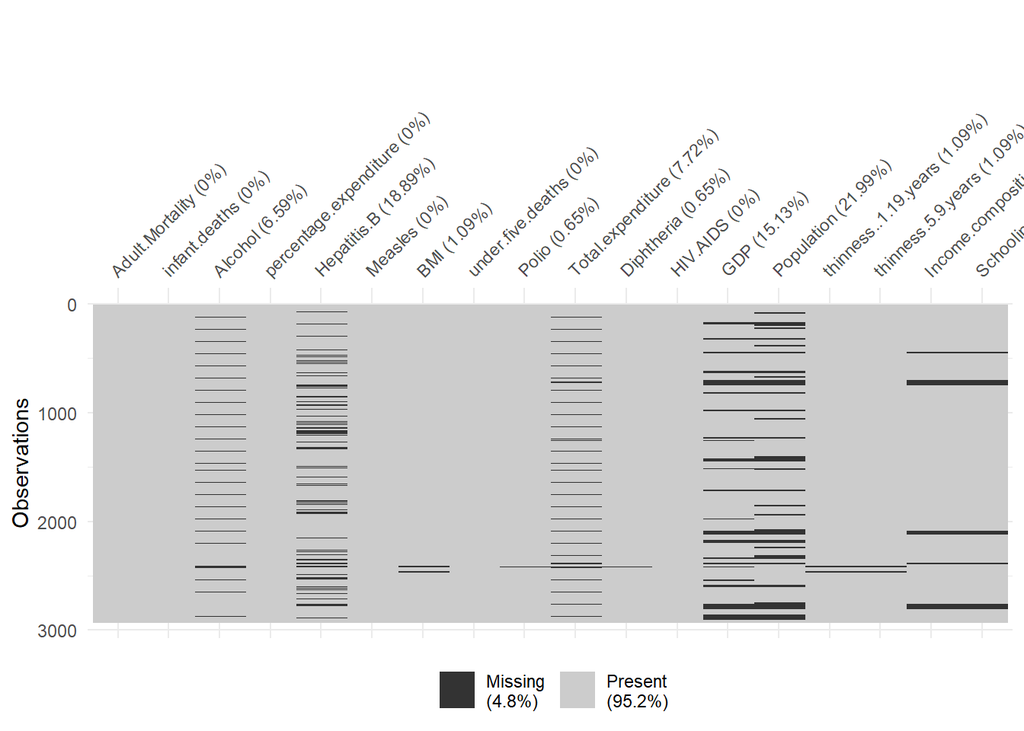

```r
# Visualise missing data
vis_miss(life[, feat_vars])
```

We see that 4.8% of the data is missing meaning that our data is 4.8% sparse, with 95.2% present indicating it is 95.2% dense. We can visualize the amount missing for each variable for different levels of life expectancy by first binning the data and then producing a heatmap:

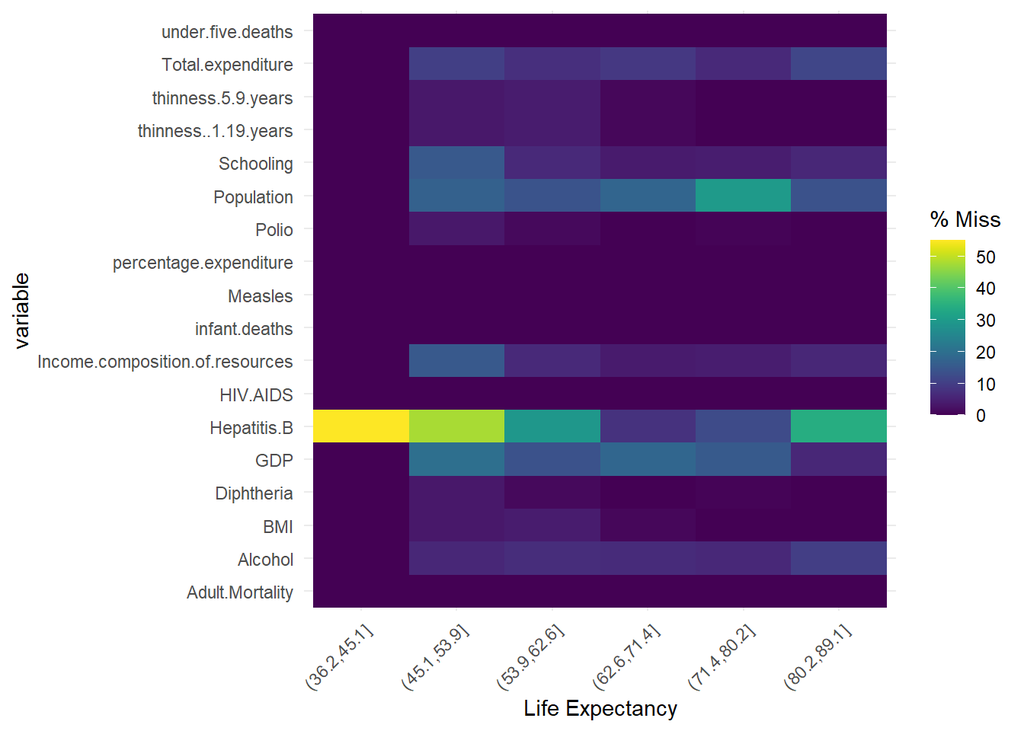

```r
t_bins <- bin(life$Life.expectancy, nbins = 6, method = "length") # Bin response variable
plot_dat <- cbind.data.frame(t_bins, life[, feat_vars])
gg_miss_fct(x = plot_dat, fct = t_bins) +
  labs(x = "Life Expectancy")
```

The main thing that sticks out from this plot is that `Hepatitus.B` is missing at a much higher rate for samples where there is a lower life expectancy. For the other variables it appears that in general we can likely classify the missingness patterns as missing completely at random, while for `Hepatitus.B` the data is likely missing at random. That is we can explain the missingness pattern using the other variables in our dataset.

We can impute missing values using the `mice` package, for this we will use classification and regression trees to impute the data, `method = "cart"`. This function generates multiple imputed datasets which can then be run through the model and the results analysed each time to determine the effect of the imputation. Here we will just generate a single imputed dataset.

```r
imputed_values <- mice( data = life[, feat_vars], # Set dataset
                        m = 1, # Set number of multiple imputations
                        maxit = 40, # Set maximum number of iterations
                        method = "cart", # Set method
                        print = FALSE) # Set whether to print output or not
```

We can then replace the missing values in our dataset with the estimates generated by mice imputation. We can do this using the `complete()` function:

```r
life[,feat_vars] <- complete(imputed_values, 1) # Extract imputed data
```

Now lets summarize our imputed features to see how they look after imputation.

```r
summary(life[, feat_vars]) # Summarize Imputed data
```

```
##  Adult.Mortality infant.deaths        Alcohol        percentage.expenditure
##  Min.   :  1.0   Min.   :   0.00   Min.   : 0.0100   Min.   :    0.000
##  1st Qu.: 74.0   1st Qu.:   0.00   1st Qu.: 0.8475   1st Qu.:    4.854
##  Median :144.0   Median :   3.00   Median : 3.6900   Median :   65.611
##  Mean   :164.8   Mean   :  30.41   Mean   : 4.5726   Mean   :  740.321
##  3rd Qu.:228.0   3rd Qu.:  22.00   3rd Qu.: 7.7000   3rd Qu.:  442.614
##  Max.   :723.0   Max.   :1800.00   Max.   :17.8700   Max.   :19479.912
##   Hepatitis.B       Measles              BMI        under.five.deaths
##  Min.   : 1.00   Min.   :     0.0   Min.   : 1.00   Min.   :   0.00
##  1st Qu.:71.00   1st Qu.:     0.0   1st Qu.:19.18   1st Qu.:   0.00
##  Median :91.00   Median :    17.0   Median :43.00   Median :   4.00
##  Mean   :77.97   Mean   :  2427.9   Mean   :38.02   Mean   :  42.18
##  3rd Qu.:96.00   3rd Qu.:   362.2   3rd Qu.:56.10   3rd Qu.:  28.00
##  Max.   :99.00   Max.   :212183.0   Max.   :77.60   Max.   :2500.00
##      Polio       Total.expenditure   Diphtheria       HIV.AIDS
##  Min.   : 3.00   Min.   : 0.370    Min.   : 2.00   Min.   : 0.100
##  1st Qu.:78.00   1st Qu.: 4.247    1st Qu.:78.00   1st Qu.: 0.100
##  Median :93.00   Median : 5.725    Median :93.00   Median : 0.100
##  Mean   :82.53   Mean   : 5.906    Mean   :82.24   Mean   : 1.748
##  3rd Qu.:97.00   3rd Qu.: 7.460    3rd Qu.:97.00   3rd Qu.: 0.800
##  Max.   :99.00   Max.   :17.600    Max.   :99.00   Max.   :50.600
##       GDP              Population        thinness..1.19.years
##  Min.   :     1.68   Min.   :3.400e+01   Min.   : 0.100
##  1st Qu.:   493.78   1st Qu.:1.847e+05   1st Qu.: 1.600
##  Median :  1862.17   Median :1.341e+06   Median : 3.400
##  Mean   :  7025.63   Mean   :1.196e+07   Mean   : 4.902
##  3rd Qu.:  5793.67   3rd Qu.:7.414e+06   3rd Qu.: 7.200
##  Max.   :119172.74   Max.   :1.294e+09   Max.   :27.700
##  thinness.5.9.years Income.composition.of.resources   Schooling
##  Min.   : 0.100     Min.   :0.0000                  Min.   : 0.00
##  1st Qu.: 1.600     1st Qu.:0.4888                  1st Qu.:10.00
##  Median : 3.400     Median :0.6770                  Median :12.30
##  Mean   : 4.933     Mean   :0.6239                  Mean   :11.92
##  3rd Qu.: 7.300     3rd Qu.:0.7810                  3rd Qu.:14.30
##  Max.   :28.600     Max.   :0.9480                  Max.   :20.70
```

As we can see the missing values in the data have been replaced with imputed values.

## Linear Regression

We can now apply a linear regression model to our dataset:

```r
use_dat <- life[, c(4:22)] # Select the columns to use for analysis
fit_1 <- lm(Life.expectancy ~., # Using ~. uses all other variables as explantory variables
            data = use_dat)
# Summarise regression
summary(fit_1)
```

```
##
## Call:
## lm(formula = Life.expectancy ~ ., data = use_dat)
##
## Residuals:
##      Min       1Q   Median       3Q      Max
## -21.8612  -2.2280  -0.0786   2.2646  16.7145
##
## Coefficients:
##                                   Estimate Std. Error t value Pr(>|t|)
## (Intercept)                      5.434e+01  5.182e-01 104.872  < 2e-16 ***
## Adult.Mortality                 -1.811e-02  7.832e-04 -23.118  < 2e-16 ***
## infant.deaths                    9.946e-02  8.214e-03  12.108  < 2e-16 ***
## Alcohol                          8.219e-02  2.310e-02   3.558 0.000379 ***
## percentage.expenditure           1.200e-04  8.014e-05   1.497 0.134444
## Hepatitis.B                      4.776e-03  3.754e-03   1.272 0.203371
## Measles                         -4.382e-06  7.477e-06  -0.586 0.557915
## BMI                              3.659e-02  4.882e-03   7.494 8.80e-14 ***
## under.five.deaths               -7.408e-02  6.021e-03 -12.303  < 2e-16 ***
## Polio                            2.692e-02  4.376e-03   6.152 8.72e-10 ***
## Total.expenditure                4.514e-02  3.208e-02   1.407 0.159478
## Diphtheria                       2.346e-02  4.858e-03   4.829 1.45e-06 ***
## HIV.AIDS                        -4.847e-01  1.712e-02 -28.311  < 2e-16 ***
## GDP                              4.906e-05  1.233e-05   3.980 7.06e-05 ***
## Population                      -6.335e-10  1.624e-09  -0.390 0.696545
## thinness..1.19.years            -7.562e-02  4.856e-02  -1.557 0.119513
## thinness.5.9.years              -7.656e-03  4.778e-02  -0.160 0.872723
## Income.composition.of.resources  6.617e+00  6.175e-01  10.716  < 2e-16 ***
## Schooling                        6.814e-01  4.089e-02  16.665  < 2e-16 ***
## ---
## Signif. codes:  0 '***' 0.001 '**' 0.01 '*' 0.05 '.' 0.1 ' ' 1
##
## Residual standard error: 3.951 on 2909 degrees of freedom
## Multiple R-squared:  0.829,  Adjusted R-squared:  0.8279
## F-statistic: 783.3 on 18 and 2909 DF,  p-value: < 2.2e-16
```

From this we see that many of the features are deemed to be significant in the model and we have a pretty high R-squared value.

## Noise

What would happen to our results if we added some noise variables to the dataset. Lets create some noise variables first. `rnorm()` generates values from a normal distribution with mean 0 and standard deviation 1.

```r
set.seed(123456) # Set seed
nonsense <- as.data.frame(matrix(rep(NA, nrow(use_dat) * 100), nrow = nrow(use_dat), ncol =100)) # Create data frame to store results
for(i in 1:ncol(nonsense)){
  nonsense[,i] <- rnorm(n = nrow(use_dat)) # Generate random variables
}
```

Now lets join them to our data frame and run the model again:

```r
# Join variables and noise
use_dat_2 <- cbind.data.frame(use_dat, nonsense)
# Run linear regression
fit_2 <- lm(Life.expectancy ~., data = use_dat_2)
# Summarise regression
summary(fit_2)
```

```
##
## Call:
## lm(formula = Life.expectancy ~ ., data = use_dat_2)
##
## Residuals:
##      Min       1Q   Median       3Q      Max
## -21.4370  -2.2170  -0.0313   2.2870  15.1195
##
## Coefficients:
##                                   Estimate Std. Error t value Pr(>|t|)
## (Intercept)                      5.433e+01  5.252e-01 103.459  < 2e-16 ***
## Adult.Mortality                 -1.798e-02  7.960e-04 -22.589  < 2e-16 ***
## infant.deaths                    9.883e-02  8.328e-03  11.867  < 2e-16 ***
## Alcohol                          8.217e-02  2.343e-02   3.507 0.000461 ***
## percentage.expenditure           1.094e-04  8.118e-05   1.347 0.178007
## Hepatitis.B                      4.364e-03  3.797e-03   1.149 0.250481
## Measles                         -2.138e-06  7.572e-06  -0.282 0.777746
## BMI                              3.609e-02  4.952e-03   7.287 4.09e-13 ***
## under.five.deaths               -7.378e-02  6.108e-03 -12.079  < 2e-16 ***
## Polio                            2.669e-02  4.449e-03   5.999 2.24e-09 ***
## Total.expenditure                4.198e-02  3.242e-02   1.295 0.195401
## Diphtheria                       2.360e-02  4.933e-03   4.784 1.81e-06 ***
## HIV.AIDS                        -4.888e-01  1.734e-02 -28.182  < 2e-16 ***
## GDP                              5.281e-05  1.250e-05   4.226 2.45e-05 ***
## Population                      -3.418e-10  1.648e-09  -0.207 0.835692
## thinness..1.19.years            -7.010e-02  4.920e-02  -1.425 0.154353
## thinness.5.9.years              -1.564e-02  4.839e-02  -0.323 0.746538
## Income.composition.of.resources  6.655e+00  6.261e-01  10.630  < 2e-16 ***
## Schooling                        6.843e-01  4.126e-02  16.587  < 2e-16 ***
## V1                              -4.301e-02  7.422e-02  -0.580 0.562285
## V2                              -8.662e-02  7.439e-02  -1.164 0.244394
## V3                               1.032e-01  7.420e-02   1.391 0.164358
## V4                              -1.562e-01  7.533e-02  -2.073 0.038228 *
## V5                              -2.009e-02  7.363e-02  -0.273 0.784983
## V6                              -7.749e-02  7.451e-02  -1.040 0.298389
## V7                               8.585e-03  7.451e-02   0.115 0.908285
## V8                              -6.230e-02  7.165e-02  -0.870 0.384634
## V9                              -2.230e-02  7.580e-02  -0.294 0.768628
## V10                              4.191e-02  7.537e-02   0.556 0.578260
## V11                             -6.277e-02  7.567e-02  -0.829 0.406894
```

[output cut: 80 more lines]

```
## V92                             -4.463e-02  7.361e-02  -0.606 0.544330
## V93                             -1.437e-01  7.494e-02  -1.917 0.055327 .
## V94                             -1.063e-01  7.387e-02  -1.440 0.150118
## V95                              4.590e-03  7.437e-02   0.062 0.950791
## V96                             -3.320e-02  7.429e-02  -0.447 0.655006
## V97                              2.684e-02  7.379e-02   0.364 0.716117
## V98                             -1.080e-01  7.329e-02  -1.474 0.140689
## V99                             -1.379e-01  7.225e-02  -1.909 0.056305 .
## V100                             2.808e-03  7.444e-02   0.038 0.969914
## ---
## Signif. codes:  0 '***' 0.001 '**' 0.01 '*' 0.05 '.' 0.1 ' ' 1
##
## Residual standard error: 3.939 on 2809 degrees of freedom
## Multiple R-squared:  0.8358, Adjusted R-squared:  0.8289
## F-statistic: 121.2 on 118 and 2809 DF,  p-value: < 2.2e-16
```

As we see from the output linear regression has found several of the nonsense variables to be significant in the model and the R^2 has increased even though those variables contain only noise. In addition each of these variables will have an impact on our predictions for new data even though they only contain noise, reducing the accuracy of predictions for this model.

## The Lasso

As an alternative to linear regression we can use the lasso model.

Prior to applying the lasso we want to scale the data which we use to have standard deviation 1 and mean 0. We can do this with the `scale()` command:

```r
# Drop missing values
use_dat_2 <- na.omit(use_dat_2)
# Scale explanatory variables
x_vars <- scale(use_dat_2[,-1])
```

We fit this model using the `glmnet()` command:

```r
#  Fit lasso model
fit_3 <- glmnet(x = x_vars, # Fit explanatory variables
                y = use_dat_2$Life.expectancy, # Fit response variable
                alpha = 1, # Set alpha as 1 for lasso
                lambda = 0.5) # Set lambda as 0.5
```

We can then view the calculated coefficients using the `coef()` command:

```r
coef(fit_3) # Print out lasso coefficients
```

```
## 119 x 1 sparse Matrix of class "dgCMatrix"
##                                         s0
## (Intercept)                     69.2249317
## Adult.Mortality                 -2.2128648
## infant.deaths                    .
## Alcohol                          .
## percentage.expenditure           .
## Hepatitis.B                      .
## Measles                          .
## BMI                              0.6319710
## under.five.deaths                .
## Polio                            0.5533469
## Total.expenditure                .
## Diphtheria                       0.5808909
## HIV.AIDS                        -2.1899541
## GDP                              0.5482574
## Population                       .
## thinness..1.19.years            -0.2479162
## thinness.5.9.years               .
## Income.composition.of.resources  1.5646975
## Schooling                        2.6372327
## V1                               .
## V2                               .
## V3                               .
## V4                               .
## V5                               .
## V6                               .
## V7                               .
## V8                               .
## V9                               .
## V10                              .
## V11                              .
## V12                              .
## V13                              .
## V14                              .
## V15                              .
## V16                              .
## V17                              .
## V18                              .
## V19                              .
```

[output cut: 66 more lines]

```
## V86                              .
## V87                              .
## V88                              .
## V89                              .
## V90                              .
## V91                              .
## V92                              .
## V93                              .
## V94                              .
## V95                              .
## V96                              .
## V97                              .
## V98                              .
## V99                              .
## V100                             .
```

We can see from the print out that the lasso model has calculated the coefficients for each of the noise variables to be zero, indicated by `.`. Thus these variables have no impact on the model and will not affect the predictions which we generate.

To compare the Lasso and linear regression coefficients we can run:

```r
temp <- coef(fit_2) # Extract coefficients from linear model
temp_2 <- as.vector(coef(fit_3)) # Extract coefficients from lasso model
cbind.data.frame(temp, temp_2) # Join coefficients together
```

```
##                                          temp     temp_2
## (Intercept)                      5.433191e+01 69.2249317
## Adult.Mortality                 -1.797994e-02 -2.2128648
## infant.deaths                    9.883329e-02  0.0000000
## Alcohol                          8.217063e-02  0.0000000
## percentage.expenditure           1.093684e-04  0.0000000
## Hepatitis.B                      4.363854e-03  0.0000000
## Measles                         -2.137589e-06  0.0000000
## BMI                              3.608659e-02  0.6319710
## under.five.deaths               -7.378322e-02  0.0000000
## Polio                            2.668964e-02  0.5533469
## Total.expenditure                4.198393e-02  0.0000000
## Diphtheria                       2.360072e-02  0.5808909
## HIV.AIDS                        -4.887817e-01 -2.1899541
## GDP                              5.281379e-05  0.5482574
## Population                      -3.418200e-10  0.0000000
## thinness..1.19.years            -7.009627e-02 -0.2479162
## thinness.5.9.years              -1.564008e-02  0.0000000
## Income.composition.of.resources  6.654913e+00  1.5646975
## Schooling                        6.843236e-01  2.6372327
## V1                              -4.301065e-02  0.0000000
## V2                              -8.661575e-02  0.0000000
## V3                               1.032097e-01  0.0000000
## V4                              -1.561844e-01  0.0000000
## V5                              -2.009138e-02  0.0000000
## V6                              -7.749339e-02  0.0000000
## V7                               8.585002e-03  0.0000000
## V8                              -6.230105e-02  0.0000000
## V9                              -2.230017e-02  0.0000000
## V10                              4.190658e-02  0.0000000
## V11                             -6.276973e-02  0.0000000
## V12                             -6.001351e-02  0.0000000
## V13                             -9.343209e-02  0.0000000
## V14                              1.666065e-01  0.0000000
## V15                             -2.417165e-02  0.0000000
## V16                             -2.290982e-03  0.0000000
## V17                              6.602482e-02  0.0000000
## V18                             -5.987921e-02  0.0000000
## V19                              1.164820e-01  0.0000000
## V20                             -1.008057e-01  0.0000000
```

[output cut: 65 more lines]

```
## V86                             -1.495445e-01  0.0000000
## V87                             -3.819716e-02  0.0000000
## V88                             -2.023828e-02  0.0000000
## V89                              1.084518e-01  0.0000000
## V90                             -6.693188e-02  0.0000000
## V91                              1.191727e-03  0.0000000
## V92                             -4.463443e-02  0.0000000
## V93                             -1.436706e-01  0.0000000
## V94                             -1.063363e-01  0.0000000
## V95                              4.589754e-03  0.0000000
## V96                             -3.319973e-02  0.0000000
## V97                              2.683591e-02  0.0000000
## V98                             -1.080102e-01  0.0000000
## V99                             -1.379493e-01  0.0000000
## V100                             2.807842e-03  0.0000000
```

#### Lasso CV

In the above example we set our lambda value manually, alternatively we can use the built in cross-validation function to calculate the lambda value to use, though this does not always produce an optimal result.

```r
# Create sequence of lambda values
lambda_seq <- seq(from = 0.1, to = 10, by = 0.1)
# Run lasso cross validation
fit_4 <- cv.glmnet(x = x_vars, # Set explanatory variables
                   y = use_dat_2$Life.expectancy, # Set response variable
                   alpha = 1, # Set alpha as 1 for lasso
                   lambda = lambda_seq, # Set lambda as sequence of lambda values
                   nfolds = 10) # Set number of folds as 10
```

We can extract the calculated lambda value using:

```r
best_lam <- fit_4$lambda.1se # Extract best lambda
best_lam # View best lambda
```

```
## [1] 0.4
```

We can then use the calculated lambda in our lasso model as:

```r
# Fit lasso model
fit_5 <- glmnet(x = x_vars, # Set x variables
                y = use_dat_2$Life.expectancy, # Set response variable
                alpha = 1, # Set alpha as 1 for lasso
                lambda = best_lam) # Set lambda as best lambda
# Print out coefficients
coef(fit_5)
```

```
## 119 x 1 sparse Matrix of class "dgCMatrix"
##                                           s0
## (Intercept)                     69.224931694
## Adult.Mortality                 -2.222522183
## infant.deaths                    .
## Alcohol                          .
## percentage.expenditure           0.004446658
## Hepatitis.B                      .
## Measles                          .
## BMI                              0.657239202
## under.five.deaths                .
## Polio                            0.589779550
## Total.expenditure                .
## Diphtheria                       0.618110009
## HIV.AIDS                        -2.252593510
## GDP                              0.601543868
## Population                       .
## thinness..1.19.years            -0.288263198
## thinness.5.9.years               .
## Income.composition.of.resources  1.568716304
## Schooling                        2.626361367
## V1                               .
## V2                               .
## V3                               .
## V4                               .
## V5                               .
## V6                               .
## V7                               .
## V8                               .
## V9                               .
## V10                              .
## V11                              .
## V12                              .
## V13                              .
## V14                              .
## V15                              .
## V16                              .
## V17                              .
## V18                              .
## V19                              .
```

[output cut: 66 more lines]

```
## V86                              .
## V87                              .
## V88                              .
## V89                              .
## V90                              .
## V91                              .
## V92                              .
## V93                              .
## V94                              .
## V95                              .
## V96                              .
## V97                              .
## V98                              .
## V99                              .
## V100                             .
```

We can also run the lasso without selecting a lambda value to use and let the algorithm try multiple values:

```r
# Fit lasso without selecting lambda
fit_6 <- glmnet(x = x_vars, # Set x variables
                y = use_dat_2$Life.expectancy, # Set response as life expectancy
                alpha = 1) # Set alpha as 1 for lasso
```

We can then determine the path of the coefficients over different values of lambda using:

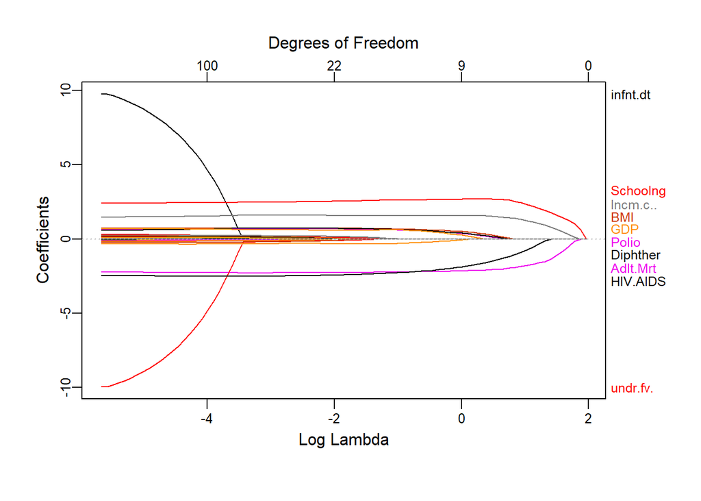

```r
plot_glmnet(fit_6, # Plot lasso coefficients by lambda
            xvar = "lambda")
```

## Exercises

For some exercises we will be analyzing some housing price data:

```r
# Load house price data
load("house_price_data.rda")
```

Lets view the data available:

```r
summary(house_price) # Summarize Housing Price Data
```

```
##  ï..LOCATION             TIME       House.Price       Education
##  Length:1182        Min.   :1980   Min.   : 24.45   Min.   : 5.058
##  Class :character   1st Qu.:1994   1st Qu.: 64.37   1st Qu.:21.574
##  Mode  :character   Median :2005   Median : 92.17   Median :29.227
##                     Mean   :2003   Mean   : 87.03   Mean   :29.277
##                     3rd Qu.:2013   3rd Qu.:105.72   3rd Qu.:37.276
##                     Max.   :2019   Max.   :175.17   Max.   :59.375
##                                                     NA's   :395
##      Wages       Exchange.rates           GDP         Health.Spending
##  Min.   :16888   Min.   :    0.430   Min.   :  3499   Min.   :  51.93
##  1st Qu.:32066   1st Qu.:    0.843   1st Qu.: 15812   1st Qu.: 256.20
##  Median :39331   Median :    1.201   Median : 25021   Median : 428.17
##  Mean   :40281   Mean   :  262.708   Mean   : 27641   Mean   : 439.98
##  3rd Qu.:49465   3rd Qu.:    7.079   3rd Qu.: 36183   3rd Qu.: 590.58
##  Max.   :70003   Max.   :14236.939   Max.   :120980   Max.   :1064.03
##  NA's   :345                         NA's   :17       NA's   :576
##  Insurance.Spending   Population      Tax.on.Property  Unemployment.rate
##  Min.   : 0.741     Min.   :-2.0590   Min.   : 0.680   Min.   : 1.558
##  1st Qu.: 3.532     1st Qu.: 0.2434   1st Qu.: 3.043   1st Qu.: 5.000
##  Median : 5.308     Median : 0.5678   Median : 5.273   Median : 7.042
##  Mean   : 6.419     Mean   : 0.7139   Mean   : 5.997   Mean   : 7.923
##  3rd Qu.: 8.174     3rd Qu.: 1.1161   3rd Qu.: 8.766   3rd Qu.: 9.608
##  Max.   :51.204     Max.   : 3.3762   Max.   :34.178   Max.   :27.492
##  NA's   :252        NA's   :42        NA's   :181      NA's   :177
```

The variables we have available are:

- Location - The country the variables relate to
- Time - The year the variables relate to
- House.Price - The housing prices indicator shows indices of residential property prices over time. The house price is given by the ratio of nominal price to the consumers expenditure in each country, both seasonally adjusted, from the OECD national accounts database.
- Education - The Education is defined as ratio of population having completed the highest level of education (tertiary education)
- Wages - Average wages are obtained by dividing the national-accounts-based total wage bill by the average number of employees in the total economy, which is then multiplied by the ratio of the average usual weekly hours per full-time employee to the average usually weekly hours for all employees. This indicator is measured in USD constant prices using 2016 base year and Purchasing Power Parities (PPPs) for private consumption of the same year.
- Exchange Rates - Exchange rates are defined as the price of one country’s’ currency in relation to another country’s currency. This indicator is measured in terms of national currency per US dollar.
- GDP - Gross domestic product (GDP) is the standard measure of the value added created through the production of goods and services in a country during a certain period.
- Health.Spending - Health spending measures the final consumption of health care goods and services including personal health care and collective services, but excluding spending on investments and is measured as a share of GDP, as a share of total health spending and in USD per capita (using economy-wide PPPs).
- Insurance.Spending - Insurance spending is defined as the ratio of direct gross premiums to GDP, which represents the relative importance of the insurance industry in the domestic economy. This indicator is expressed as a percentage of GDP.
- Population - Total population of the country in a given year.
- Tax.on.Property - Tax on property is defined as recurrent and non-recurrent taxes on the use, ownership or transfer of property and is measured in percentage of total taxation.
- Unemployment.rate - The unemployed are people of working age who are without work, are available for work, and have taken specific steps to find work. This indicator is measured in numbers of unemployed people as a percentage of the labor force and it is seasonally adjusted.

The objective of our analysis is to be able to identify the factors which determine house price in each of the countries.

Please complete the following exercises:

- Visualize the missing data for the housing price dataset.

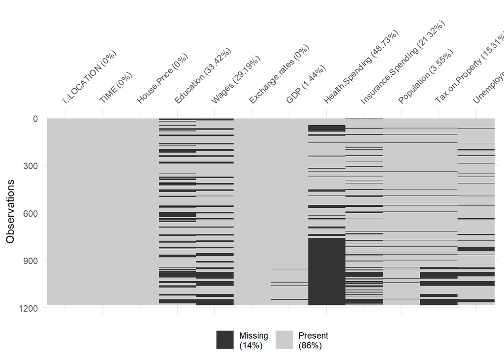

```r
vis_miss(house_price)
```

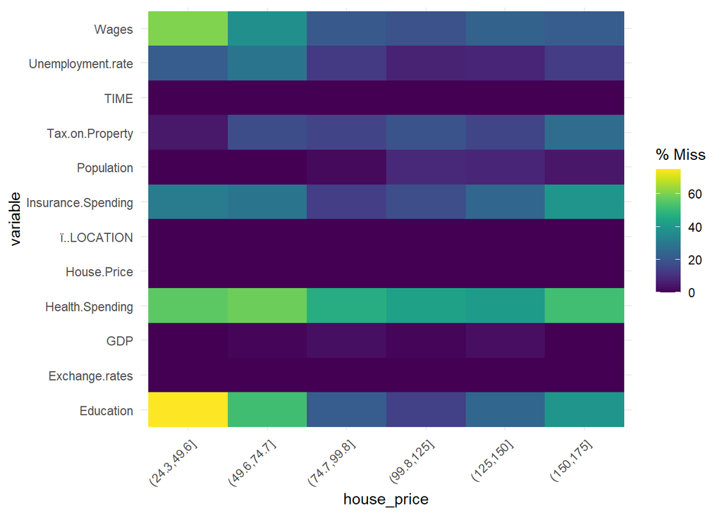

```r
t_bins <- bin(house_price$House.Price, nbins = 6, method = "length")
plot_dat <- cbind.data.frame(t_bins, house_price)
gg_miss_fct(x = plot_dat, fct = t_bins) +
  labs(x = "house_price")
```

- Impute the missing data values for the housing price dataset.

```r
imputed_values <- mice(data = house_price[,2:dim(house_price)[2]],
                       m = 1,
                       maxit = 40,
                       method = "cart",
                       print = F)
house_price[,2:dim(house_price)[2]] <- complete(imputed_values, 1)
summary(house_price)
```

```
##  ï..LOCATION             TIME       House.Price       Education
##  Length:1182        Min.   :1980   Min.   : 24.45   Min.   : 5.058
##  Class :character   1st Qu.:1994   1st Qu.: 64.37   1st Qu.:15.625
##  Mode  :character   Median :2005   Median : 92.17   Median :24.219
##                     Mean   :2003   Mean   : 87.03   Mean   :25.420
##                     3rd Qu.:2013   3rd Qu.:105.72   3rd Qu.:34.054
##                     Max.   :2019   Max.   :175.17   Max.   :59.375
##      Wages       Exchange.rates           GDP         Health.Spending
##  Min.   :16888   Min.   :    0.430   Min.   :  3499   Min.   :  51.93
##  1st Qu.:26255   1st Qu.:    0.843   1st Qu.: 15787   1st Qu.: 238.12
##  Median :36849   Median :    1.201   Median : 24995   Median : 401.27
##  Mean   :36897   Mean   :  262.708   Mean   : 27582   Mean   : 417.95
##  3rd Qu.:45767   3rd Qu.:    7.079   3rd Qu.: 36163   3rd Qu.: 574.78
##  Max.   :70003   Max.   :14236.939   Max.   :120980   Max.   :1064.03
##  Insurance.Spending   Population      Tax.on.Property  Unemployment.rate
##  Min.   : 0.741     Min.   :-2.0590   Min.   : 0.680   Min.   : 1.558
##  1st Qu.: 3.083     1st Qu.: 0.2408   1st Qu.: 3.180   1st Qu.: 5.008
##  Median : 4.976     Median : 0.5678   Median : 5.311   Median : 7.220
##  Mean   : 6.131     Mean   : 0.7128   Mean   : 6.045   Mean   : 8.211
##  3rd Qu.: 7.867     3rd Qu.: 1.1180   3rd Qu.: 8.716   3rd Qu.: 9.800
##  Max.   :51.204     Max.   : 3.3762   Max.   :34.178   Max.   :27.492
```

- Run a linear regression with housing price as the response variable (Leave out country).

```r
lm_full <- lm(House.Price~., data = house_price[,2:dim(house_price)[2]])
summary(lm_full)
```

```
##
## Call:
## lm(formula = House.Price ~ ., data = house_price[, 2:dim(house_price)[2]])
##
## Residuals:
##     Min      1Q  Median      3Q     Max
## -43.533 -15.888  -4.123  10.149  89.343
##
## Coefficients:
##                      Estimate Std. Error t value Pr(>|t|)
## (Intercept)        -2.354e+03  2.463e+02  -9.556  < 2e-16 ***
## TIME                1.225e+00  1.237e-01   9.906  < 2e-16 ***
## Education          -5.071e-01  9.818e-02  -5.164 2.83e-07 ***
## Wages              -2.666e-04  1.022e-04  -2.609  0.00919 **
## Exchange.rates      6.722e-04  5.360e-04   1.254  0.21006
## GDP                 9.923e-05  1.220e-04   0.814  0.41603
## Health.Spending     3.224e-02  5.930e-03   5.437 6.59e-08 ***
## Insurance.Spending  2.954e-01  2.014e-01   1.466  0.14285
## Population         -4.151e+00  9.913e-01  -4.187 3.04e-05 ***
## Tax.on.Property     5.863e-01  2.271e-01   2.582  0.00996 **
## Unemployment.rate  -1.158e+00  1.692e-01  -6.843 1.25e-11 ***
## ---
## Signif. codes:  0 '***' 0.001 '**' 0.01 '*' 0.05 '.' 0.1 ' ' 1
##
## Residual standard error: 23.5 on 1171 degrees of freedom
## Multiple R-squared:  0.3787, Adjusted R-squared:  0.3734
## F-statistic: 71.37 on 10 and 1171 DF,  p-value: < 2.2e-16
```

- Which variables are significant in the linear regression?

```r
lm_bwd <- step(lm_full, k = log(dim(house_price)[1]), direction = "backward")
```

```
## Start:  AIC=7530.03
## House.Price ~ TIME + Education + Wages + Exchange.rates + GDP +
##     Health.Spending + Insurance.Spending + Population + Tax.on.Property +
##     Unemployment.rate
##
##                      Df Sum of Sq    RSS    AIC
## - GDP                 1       366 647112 7523.6
## - Exchange.rates      1       869 647615 7524.5
## - Insurance.Spending  1      1187 647933 7525.1
## - Tax.on.Property     1      3681 650427 7529.7
## - Wages               1      3760 650506 7529.8
## <none>                            646746 7530.0
## - Population          1      9683 656429 7540.5
## - Education           1     14731 661477 7549.6
## - Health.Spending     1     16326 663072 7552.4
## - Unemployment.rate   1     25862 672608 7569.3
## - TIME                1     54194 700940 7618.1
##
## Step:  AIC=7523.63
## House.Price ~ TIME + Education + Wages + Exchange.rates + Health.Spending +
##     Insurance.Spending + Population + Tax.on.Property + Unemployment.rate
##
##                      Df Sum of Sq    RSS    AIC
## - Exchange.rates      1       751 647862 7517.9
## - Insurance.Spending  1      2815 649927 7521.7
## - Tax.on.Property     1      3321 650432 7522.6
## <none>                            647112 7523.6
## - Wages               1      3984 651096 7523.8
## - Population          1      9583 656695 7533.9
## - Education           1     14712 661824 7543.1
## - Health.Spending     1     17905 665016 7548.8
## - Unemployment.rate   1     28476 675588 7567.5
## - TIME                1     71597 718709 7640.6
##
## Step:  AIC=7517.92
## House.Price ~ TIME + Education + Wages + Health.Spending + Insurance.Spending +
##     Population + Tax.on.Property + Unemployment.rate
##
##                      Df Sum of Sq    RSS    AIC
## - Insurance.Spending  1      2694 650556 7515.8
```

[output cut: 20 more lines]

```
## - Unemployment.rate  1     27404 677960 7557.4
## - TIME               1     82029 732585 7649.0
##
## Step:  AIC=7512.58
## House.Price ~ TIME + Education + Health.Spending + Population +
##     Tax.on.Property + Unemployment.rate
##
##                     Df Sum of Sq    RSS    AIC
## <none>                           652706 7512.6
## - Tax.on.Property    1      4711 657418 7514.0
## - Population         1      8345 661052 7520.5
## - Health.Spending    1     15148 667854 7532.6
## - Unemployment.rate  1     25722 678429 7551.2
## - Education          1     28630 681336 7556.2
## - TIME               1     93965 746671 7664.5
```

```r
var_list <- data.frame(summary(lm_full)$coefficient)
row.names(var_list[var_list$Pr...t.. <= 0.1,])
```

```
## [1] "(Intercept)"       "TIME"              "Education"
## [4] "Wages"             "Health.Spending"   "Population"
## [7] "Tax.on.Property"   "Unemployment.rate"
```

- Run a lasso regression with housing price as the response variable.

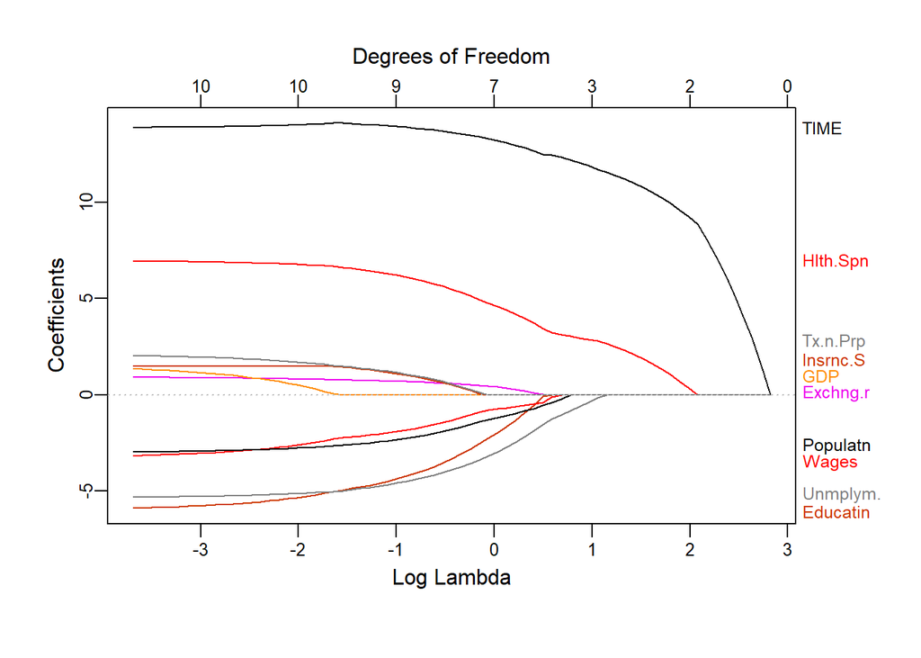

```r
x_var <- scale(house_price[,c(-1,-3)])
fit <- glmnet(x = x_var,
              y = house_price$House.Price,
              alpha = 1)
plot_glmnet(fit,
            xvar =  "lambda")
```

```r
fit2 <- glmnet(x = x_var,
              y = house_price$House.Price,
              alpha = 1,
              lambda = 0.5)
coef(fit2)
```

```
## 11 x 1 sparse Matrix of class "dgCMatrix"
##                            s0
## (Intercept)        87.0311125
## TIME               13.7990284
## Education          -3.8795212
## Wages              -1.6337902
## Exchange.rates      0.6474553
## GDP                 .
## Health.Spending     5.8705223
## Insurance.Spending  0.8297321
## Population         -2.0795773
## Tax.on.Property     0.8768917
## Unemployment.rate  -4.2660199
```

- Which variables have a non-zero coefficient in the lasso regression? TIME  
  Education Wages Exchange.rates Health.Spending Insurance.Spending Population Tax.on.Property Unemployment.rate